# Non-Diagonal Case

## 5.1 The output from the fit

Here is the fitted spline curve to the number of unmarked fish available in each recovery sample

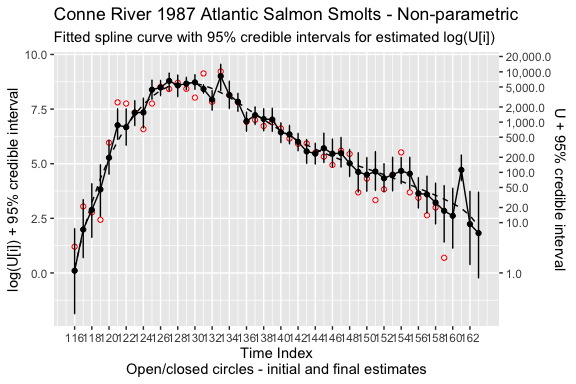

Fitted spline curve

```r
demo2.fit$plots$fit.plot
```

The distribution of the posterior sample for the total number unmarked and total abundance is available:

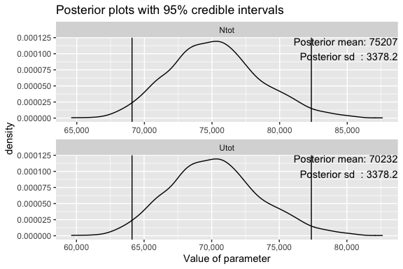

Distribution of posterior samples

```r
demo2.fit$plots$post.UNtot.plot
```

A plot of the $logit(P)$ is

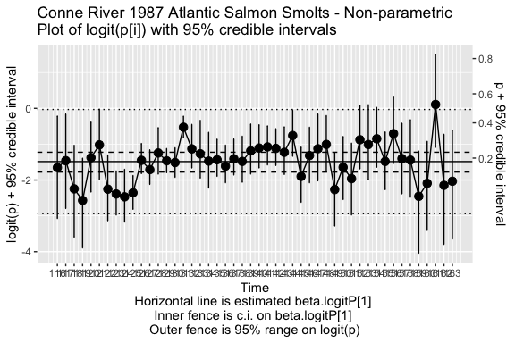

Estimates of logit(p)

```r
demo2.fit$plots$logitP.plot
```

In cases where there is little information, $BTSPAS$ has shared information based on the distribution of catchability in the other strata.

A summary of the posterior for each parameter is also available. In particular, here are the summary statistics on the posterior sample for the total number unmarked and total abundance:

```r
demo2.fit$summary[ row.names(demo2.fit$summary) %in% c("Ntot","Utot"),]
```

```
#>         mean       sd     2.5%      25%     50%      75%    97.5%     Rhat n.eff
#> Ntot 75206.6 3378.243 69084.17 72874.25 75089.5 77285.25 82345.89 1.002336   860
#> Utot 70231.6 3378.243 64109.17 67899.25 70114.5 72310.25 77370.89 1.002343   850
```

This also includes the Rubin-Brooks-Gelman statistic ($Rhat$) on mixing of the chains and the effective sample size of the posterior (after accounting for autocorrelation).

The estimated total abundance from $BTSPAS$ is 75,207 (SD 3,378 ) fish.

The estimated distribution function is allowed by vary by release stratum around a common “mean” distribution.

```r
probs <- demo2.fit$summary[grepl("movep", row.names(demo2.fit$summary)),  ]
round(probs,3)
```

```
#>           mean    sd  2.5%   25%   50%   75% 97.5%  Rhat n.eff
#> movep[1] 0.020 0.008 0.009 0.015 0.019 0.024 0.038 1.002  1500
#> movep[2] 0.450 0.069 0.315 0.404 0.448 0.495 0.583 1.000  1500
#> movep[3] 0.398 0.061 0.270 0.359 0.398 0.439 0.519 1.000  1500
#> movep[4] 0.104 0.030 0.056 0.083 0.101 0.122 0.169 1.001  1500
#> movep[5] 0.028 0.012 0.011 0.019 0.026 0.035 0.057 1.000  1500
```

So we expect that about 2% of fish will migrate to the second trap in the day of release; about 45% of fish will migrate to the second trap in the second day after release etc.

The movement for each release stratum varies around this base distribution. It is also possible to see the probability of moving from release stratum $i$ to recovery stratum $j$ by looking at the $Theta[i,j]$ values. Here are the transition probabilities for the first release stratum:

```r
round(demo2.fit$summary[ grepl("Theta[1,", row.names(demo2.fit$summary),fixed=TRUE),],3)
```

```
#>             mean    sd  2.5%   25%   50%   75% 97.5%  Rhat n.eff
#> Theta[1,1] 0.036 0.060 0.001 0.006 0.016 0.042 0.198 1.001  1500
#> Theta[1,2] 0.230 0.173 0.020 0.095 0.187 0.328 0.666 1.000  1500
#> Theta[1,3] 0.291 0.187 0.029 0.139 0.258 0.418 0.712 1.001  1500
#> Theta[1,4] 0.183 0.139 0.015 0.076 0.151 0.254 0.540 1.000  1500
#> Theta[1,5] 0.259 0.160 0.037 0.133 0.231 0.368 0.629 1.005  1500
```

The probabilities should also sum to 1 for each release group.

It is always important to do model assessment before accepting the results from the model fit. Please contact me for details on how to interpret the goodness of fit, trace, and autocorrelation plots.